# PCFL: Week 11 wrap-up

### Last week’s games

| Away | Away points | Home | Home points |
| --- | --- | --- | --- |
| Southern Sharks | 110.48 | Middle Earth Hangry Hobbits | 131.56 |
| The G.O.A.T. | 116.86 | Athens Team Sasquatch | 109.64 |
| Jumpin’ Jaheims | 119.06 | Captain Clairvoyant | 94.34 |
| First Timers The FTs | 108.52 | KC Gophers | 79.59 |
| Georgia Peanuts | 145.36 | Pigskin on the Gridiron | 96.04 |

A couple of teams in need of a win came through this week. The Jumpin’ Jaheims took down the league leading Captian Clairvoyant, and The Hangry Hobbits ate up the Sharks. The First Timers broke a long losing streak as Christine’s Gophers had an unexpectedly down week. The other league leader, Robbie, also lost to Jacob’s G.O.A.T. Lastly, my Peanuts came through against Richard’s team.

We’re almost done with bye weeks–none this week and just two (Carolina and Tampa Bay) next week. But as always, keep an eye on COVID and injury related news.

#### Best performing players

Here’s last week’s **10 best performing players.**

| Player | Points | Team |
| --- | --- | --- |
| Deshaun Watson | 31.36 | Middle Earth Hangry Hobbits |
| Adam Thielen | 28.30 | First Timers The FTs |
| Justin Herbert | 27.74 | Georgia Peanuts |
| Keenan Allen | 26.50 | Middle Earth Hangry Hobbits |
| Robert Woods | 24.60 | Pigskin on the Gridiron |
| Taysom Hill | 24.42 | Georgia Peanuts |
| Jared Goff | 23.04 | The G.O.A.T. |
| Kirk Cousins | 22.96 | Jumpin’ Jaheims |
| Travis Kelce | 22.86 | KC Gophers |
| Dalvin Cook | 22.50 | Georgia Peanuts |

Not a breakout week for anyone, with only Deshaun Watson breaking 30 points. But Watson and Keenan Allen helped power Scott’s win. Among non-QBs, Adam Thielen also had a very nice week.

#### Best addition and worst starters

There were 26 players added last week. Which was the **best new addition**?

| Date added | Name | Points | Team |
| --- | --- | --- | --- |
| 2020-11-19 | Taysom Hill | 24.42 | Georgia Peanuts |
| 2020-11-22 | Kirk Cousins | 22.96 | Jumpin’ Jaheims |
| 2020-11-18 | Browns D/ST | 20.00 | Jumpin’ Jaheims |
| 2020-11-21 | Dallas Goedert | 16.20 | The G.O.A.T. |
| 2020-11-18 | Michael Pittman Jr. | 15.10 | Southern Sharks |
| 2020-11-18 | Damien Harris | 11.90 | Georgia Peanuts |
| 2020-11-19 | James Conner | 11.40 | Southern Sharks |
| 2020-11-18 | Chargers D/ST | 11.00 | Southern Sharks |
| 2020-11-18 | Kalen Ballage | 10.60 | Athens Team Sasquatch |
| 2020-11-18 | Salvon Ahmed | 9.90 | Southern Sharks |
| 2020-11-19 | Latavius Murray | 9.50 | Athens Team Sasquatch |
| 2020-11-21 | La’Mical Perine | 9.30 | The G.O.A.T. |
| 2020-11-21 | Jamaal Williams | 8.10 | KC Gophers |
| 2020-11-20 | Giovani Bernard | 7.50 | Athens Team Sasquatch |
| 2020-11-20 | Noah Fant | 7.50 | Pigskin on the Gridiron |
| 2020-11-18 | Rams D/ST | 7.00 | Georgia Peanuts |
| 2020-11-18 | Mike Gesicki | 6.30 | Jumpin’ Jaheims |
| 2020-11-22 | DJ Chark Jr. | 6.10 | First Timers The FTs |
| 2020-11-21 | Ryan Succop | 6.00 | The G.O.A.T. |
| 2020-11-19 | Jerry Jeudy | 5.20 | Georgia Peanuts |
| 2020-11-19 | Malcolm Brown | 3.30 | Georgia Peanuts |
| 2020-11-22 | Vikings D/ST | 3.00 | First Timers The FTs |
| 2020-11-18 | Jakeem Grant | 2.80 | Athens Team Sasquatch |
| 2020-11-18 | Rex Burkhead | 2.20 | Athens Team Sasquatch |
| 2020-11-19 | Myles Gaskin | 0.00 | Georgia Peanuts |
| 2020-11-18 | Jameis Winston | 0.00 | Southern Sharks |

Several nice adds this week by Evan (Kirk Cousins and the Browns D/ST) and Sarah (Michael Pittman,James Connor, and the Chargers D/ST). Certainly an argument for the value of the streaming defense–going just based on matchup.

Who won the **best scoring bench** award last week?

| Team | Points |
| --- | --- |
| The G.O.A.T. | 106.14 |
| Middle Earth Hangry Hobbits | 67.56 |
| Athens Team Sasquatch | 62.90 |
| Georgia Peanuts | 61.38 |
| Pigskin on the Gridiron | 60.97 |
| KC Gophers | 57.82 |
| Captain Clairvoyant | 54.00 |
| First Timers The FTs | 51.50 |
| Jumpin’ Jaheims | 50.60 |
| Southern Sharks | 33.10 |

The G.O.A.T. won their game, but also had plenty left on the bench.

### League standings and season stats

Here’s a look at our current standings

| Team | Division | W | L | Points scored | Points allowed | Points rank | Playoff rank |
| --- | --- | --- | --- | --- | --- | --- | --- |
| Georgia Peanuts | Hot Dish | 8 | 3 | 1419.16 | 1187.96 | 1 | 1 |
| Captain Clairvoyant | Grits | 8 | 3 | 1279.57 | 1175.26 | 2 | 2 |
| Athens Team Sasquatch | Grits | 8 | 3 | 1227.70 | 1174.64 | 3 | 3 |
| The G.O.A.T. | Grits | 7 | 4 | 1191.89 | 1233.46 | 6 | 4 |
| Southern Sharks | Hot Dish | 5 | 6 | 1179.86 | 1176.77 | 7 | 5 |
| KC Gophers | Hot Dish | 5 | 6 | 1157.20 | 1199.15 | 8 | 6 |
| First Timers The FTs | Hot Dish | 4 | 7 | 1192.82 | 1237.06 | 5 | 7 |
| Pigskin on the Gridiron | Grits | 4 | 7 | 1143.40 | 1275.90 | 9 | 8 |
| Middle Earth Hangry Hobbits | Hot Dish | 3 | 8 | 1216.52 | 1261.27 | 4 | 9 |
| Jumpin’ Jaheims | Grits | 3 | 8 | 1136.50 | 1223.15 | 10 | 10 |

Here’s our current awards leaders from these standings:

- Yellow shirt (most points): Georgia Peanuts
- D-FENCE (least points allowed): Team Sasquatch (*new*)
- Tough luck (points rank - playoff rank): Hobbits (4th in points and 9th in the standings)
- Lucky ducks (playoff rank - points rank): The GOAT, Sharks, and Gophers are all tied here.

Here’s a list of the **top five scoring performances** so far this season.

| Team | Week | Points scored | Result |
| --- | --- | --- | --- |
| Georgia Peanuts | 8 | 183.82 | W |
| First Timers The FTs | 2 | 171.28 | W |
| Georgia Peanuts | 7 | 163.68 | W |
| Georgia Peanuts | 9 | 152.14 | W |
| Captain Clairvoyant | 3 | 150.32 | W |

No changes this week.

Lastly, here’s a look at the **points trendline** for each team.

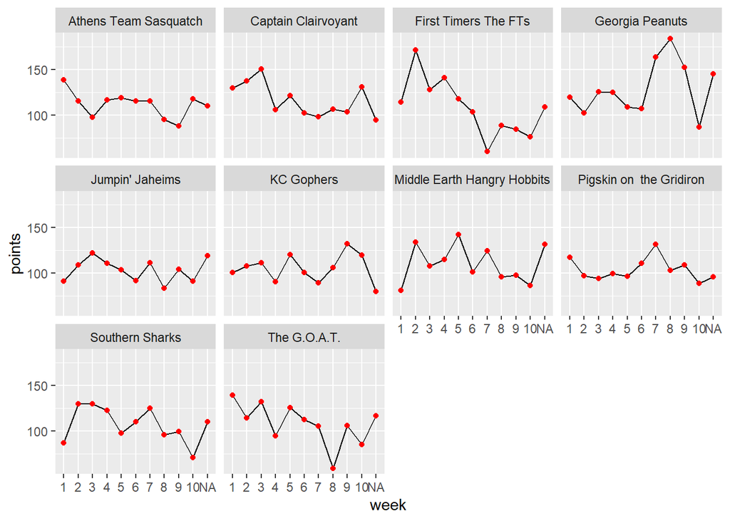

### Playoff picture

There’s now three weeks left in the season. If it ended today, our division leaders would be me and Brian (tied with Robbie, but winner on points). The wildcards would be Robbie and Jacob. Sarah and Christine are two games back for that last wild card spot, so it’s still a possibility. Erin & Trav and Richard are still technically alive, but they’d need some really lucky breaks. If I’m reading these right, I think Evan and Scott are now technically eliminated. But there are always the consolation brackets!

## Next week’s games

Here’s a quick summary of next week’s matchups:

| week | away_team | away_points | home_team | home_points | range |
| --- | --- | --- | --- | --- | --- |
| 12 | Captain Clairvoyant | 1279.57 | The G.O.A.T. | 1191.89 | 87.68 |
| 12 | Middle Earth Hangry Hobbits | 1216.52 | First Timers The FTs | 1192.82 | 23.70 |
| 12 | Pigskin on the Gridiron | 1143.40 | Southern Sharks | 1179.86 | 36.46 |
| 12 | Athens Team Sasquatch | 1227.70 | KC Gophers | 1157.20 | 70.50 |
| 12 | Georgia Peanuts | 1419.16 | Jumpin’ Jaheims | 1136.50 | 282.66 |

Many teams’ playoff hopes hinge on the GOAT losing, and he’s matched up with Brian this week, making it the key game of the week. Among the other leaders, I play Evan and Robbie plays Christine (another important matchup). Sarah needs a win against Richard to stay in the playoff hunt. The Hobbits have racked up points this season, even if their record doesn’t show it, and they face the First Timers this week. Good luck all!